# Comment manipuler et faire parler les données spatiales de revenus diffusées par l’Insee ?

ATELIER DATAJOURNALISTES

28/11/2023

# 1 Comment mesurer la pauvreté ?

## 1.1 Qu’est-ce que la pauvreté ?

Pour commencer…

Avoir un faible revenu, percevoir des minima sociaux, ne pas avoir de logement, se priver de certaines dépenses, recourir à l’aide alimentaire…

➡️ la pauvreté est un phénomène **multidimensionnel**

Parmi elles, deux dimensions sont mesurées régulièrement par la statistique publique :

- La **pauvreté monétaire**
  - une mesure relative basée sur les revenus, qui compare le *niveau de vie* par rapport au *seuil de pauvreté*
- La **pauvreté en conditions de vie**
  - traduit l’incapacité à couvrir les dépenses de la vie courante pour avoir un niveau de vie acceptable

**Dans cet atelier, focus sur la **pauvreté** **monétaire, au niveau local****

*Objectif* : appréhender les différences de revenus entre les territoires

## 1.2 La pauvreté monétaire

Une mesure relative déterminée à partir du **seuil de pauvreté** = 60% du niveau de vie médian

**Définition de la **pauvreté monétaire****

Une personne est pauvre lorsqu’elle vit dans un **ménage dont le niveau de vie est inférieur au seuil de pauvreté**, fixé à 60 % du niveau de vie médian de la population. *En 2021, 14,5% des personnes sont pauvres en France*

**Définition du **niveau de vie****

Le **niveau de vie** d’un ménage est son **revenu disponible** *(= revenu après redistribution, à la disposition du ménage pour consommer et épargner)* divisé par le nombre d’**unités de consommation** (UC). Le niveau de vie est donc le même pour tous les individus d’un même ménage.  
*Échelle d’équivalence de l’OCDE* : 1 UC au premier adulte du ménage, 0,5 UC aux autres personnes de 14 ans ou plus et 0,3 UC aux enfants de moins de 14 ans.

2 sources principales :

- au niveau national : l’**Enquête Revenus Fiscaux et Sociaux** (ERFS) permet de disposer de la distribution complète des revenus (appariement enquête emploi et revenus)
- au niveau local : le dispositif **Filosofi**, construit à partir des sources socio-fiscales : une source quasi-exhaustive disponible à un niveau territorial très fin et adaptée pour les comparaisons entre territoires

# 2 À la découverte des données spatiales de revenus

## 2.1 Focus sur le dispositif *Filosofi*

- Des indicateurs clés :
  - Distribution du **niveau de vie** (médiane, D1, D9…), **taux de pauvreté**
  - Décomposition du revenu disponible (part des salaires, des retraites, des prestations sociales…)
  - … croisés avec des **caractéristiques sociodémographiques** (âge, le statut d’occupation du logement…)
- Diffusés sur le champ de la **France métropolitaine + Martinique + La Réunion**
  - Pour la Guadeloupe, la Guyane et Mayotte c’est l’enquête *Budget de famille* qui est utilisée pour produire des indicateurs de revenus et de pauvreté.
- Sur de **nombreux niveaux géographiques** :
  - Niveaux administratifs : de la région à la commune *(sous réserve du respect du secret statistique - voir plus loin)*
  - Zonages d’études de l’Insee : zones d’emploi, aires d’attraction des villes…
  - Et aussi : données à l’Iris, données sur les QPV, **données carroyées**
- Calendrier (hors données carroyées) : diffusion des données du millésime *N* (= revenus de l’année *N*) à partir de janvier *N+3*

## 2.2 Première approche sur le site **Statistiques locales**

Où trouver les données ? (1/2)

https://statistiques-locales.insee.fr

- Sur la page d’accueil, cliquer sur *Indicateurs*
- Dans le panneau de gauche, choisir l’indicateur du **Taux de pauvreté 2020** (*Revenus - Pouvoir d’achat - consommation* > *Pauvreté - Précarité*)
- Toujours dans le panneau de gauche, vous pouvez choisir le *niveau géographique* sur lequel cartographier les données

## Titre transparent

Où trouver les données ? (1/2)

**Exercice 1**

**Questions**

**1**. Quel est le département de France Métropolitaine avec le taux de pauvreté le plus faible ? le plus élevé ?

**2**. Parmi les intercommunalités de + 300 000 habitants, quelle est celle qui a le taux de pauvreté le plus élevé ?

**Indices**

- Vous pouvez représenter plusieurs variables sur la même carte.
- Vous pouvez afficher le tableau des données en parallèle de la carte en cliquant sur le bouton **+** à côté de `CARTE` au-dessus de la carte, puis sur `CARTE + TABLEAU`. Cliquer sur les colonnes du tableau permet de les trier. À droite, le bouton `ACTIONS` propose une fonctionnalité de tri sur les différentes variables affichées.

## Titre transparent

Où trouver les données ? (1/2)

**Solutions**

**1**. Le département de France métropolitaine avec le taux de pauvreté :  
- le plus **faible** : 85 - **Vendée** (8.9%)  
- le plus **élevé** : 93 - **Seine-Saint-Denis** (27.6%)

**2**. L’intercommunalité de 300 000 habitants ou plus avec le taux de pauvreté le plus élevé est la **Communauté d’Agglomération de Roissy Pays de France** (22.8%)

*À savoir*

Le site [*Statistiques locales*](https://statistiques-locales.insee.fr) offre de nombreuses fonctionnalités : paramétrage des cartes, export des données, comparaison de territoires, édition de rapports… voir le [mode d’emploi simplifié](https://www.insee.fr/fr/statistiques/fichier/3544265/mode_emploi_statistiques_locales_simplifie.pdf) pour en savoir plus.

## 2.3 Fichiers détaillés téléchargeables sur [insee.fr](https://www.insee.fr/fr/accueil)

Où trouver les données ? (2/2)

**Niveaux communaux et supracommunaux**

- [*Principaux résultats sur les revenus et la pauvreté des ménages en 2020*](https://www.insee.fr/fr/statistiques/6692392?sommaire=6692394)
  - Une publication + un fichier à télécharger (csv ou xlsx) pour tous les niveaux géographiques
  - Davantage de variables et de niveaux géographiques que sur *Statistiques Locales* (géographie au 01/01/2023)
- [*Structure et distribution des revenus, inégalité des niveaux de vie en 2020*](https://www.insee.fr/fr/statistiques/6692220)
  - Indicateurs très détaillés sur les revenus déclarés (avant redistribution), les revenus disponibles (après redistribution) et les niveaux de vie
  - 1 fichier par champ d’analyse x sous population x niveau géographique (géographie au 01/01/2021)
    - *Par exemple :* le niveau de vie médian des femmes pauvres occupant seules leur logement en Provence-Alpes-Côte-d’Azur ?
    - *Réponse : 10 790€ annuels en 2020*

**Note**

Un de ces nombreux fichiers, nommé `cc_filosofi_2020_COM.csv` vous servira durant l’**Exercice 2** de cartographie sur R.

## Titre transparent

**Niveaux infracommunaux**

- [Bases à l’**IRIS**](https://www.insee.fr/fr/statistiques/7233950)
  - Sur les IRIS des communes d’au moins 5000 habitants
- [Données sur les **quartiers de la politique de la ville**](https://www.insee.fr/fr/statistiques/7231733?sommaire=2500477)
- [**Données carroyées** (Filosofi 2019)](https://www.insee.fr/fr/statistiques/7655515)

*À savoir*

Pour retrouver ces pages, utiliser la barre de recherche sur insee.fr et saisir `filosofi` !

## 2.4 Quelques précautions avec Filosofi

**Limites de la source**

- **La mesure du revenu dans Filosofi est incomplète** : certains revenus, notamment ceux exonérés d’impôts (prime exceptionnelle de pouvoir d’achat, prime Covid versées aux personnels soignants etc.) peuvent manquer certaines années.
- **Le degré de couverture de la population peut varier d’une année sur l’autre**.

**Conséquences**

- L’utilisation de Filosofi est centrée sur les **comparaisons entre territoires**.
- Filosofi est à utiliser en **statique** : les évolutions peuvent ne pas représenter des variations de revenus mais des changements dans le degré de couverture des revenus ou de la population.

**Quelques références**

- [*L’Essentiel sur…la pauvreté*](https://www.insee.fr/fr/statistiques/5759045#onglet-1)
- [*Le Tableau de Bord de l’Économie française*](https://www.insee.fr/fr/outil-interactif/5367857/territoires/30_RPC/33_PAU)
- [*Pauvreté et territoires : davantage de jeunes et de locataires du parc social dans les grandes villes, plus de retraités parmi les pauvres dans le rural*](https://www.insee.fr/fr/information/7676709) : une publication nationale + un dossier pour chaque région

## Titre transparent

**Exercice 2**

**Objectif** : Réaliser la carte suivante du **niveau de vie** par **commune** en Normandie, en mobilisant les données de Filosofi.

[figure not shown]

# 3 Manipuler et interpréter des données au carreau

## Titre transparent

Visualisation interactive en ligne

Les données de Filosofi sont également disponibles sur des **carreaux**

de **1km**

[figure not shown]

https://statistiques-locales.insee.fr

de **200m**

[figure not shown]

https://www.geoportail.gouv.fr

## Titre transparent

Variables mises à disposition

- Légèrement **différentes** que pour les autres zonages (additives)
  - Revenu médian ➡️ Revenu moyen = Somme des niveaux de vie winsorisés / Nombre d’individus
  - Taux de pauvreté ➡️ Part de ménages pauvres = Nombre de ménages pauvres / Nombre de ménages
- Balayent un **spectre plus large** que la seule thématique de la pauvreté
  - Ancienneté des logements
  - Composition des ménages
  - …

## Titre transparent

Interprétation des cartes

- Les carreaux permettent de s’**abstraire des zonages administratifs** tels que la commune
- Le prix à payer pour ce niveau de finesse d’information est la **gestion du secret statistique**.

*79 % des carreaux habités de France métropolitaine comprennent moins de 11 ménages fiscaux et doivent faire l’objet d’une imputation.*

➡️ C’est pourquoi les données carroyées ne s’apprécient pas « carreau » par « carreau » mais sur un **paysage de carreaux** permettant, par exemple, d’identifier des poches de pauvreté au sein des villes.

## Titre transparent

**Exercice 3**

**Objectif** : Réaliser la carte suivante du **revenu moyen** par **carreau de 1km** en Seine-Saint-Denis (93), en mobilisant les données de Filosofi.

[figure not shown]

Merci de votre attention

Retrouvez nous sur

- Kim Antunez
- Solène Colin
- Mathilde Gerardin
- Direction Générale de l’Insee
- Département de l’action régionale

## Titre transparent

Annexe - Quels sont les territoires les plus pauvres ?

- Le taux de pauvreté est plus élevé en Outre-Mer, dans le Nord de la France, autour de l’arc méditerrannéen et en Seine-Saint-Denis
- D’importantes disparités entre les territoires, à plusieurs échelles :
  - à l’infra-régional : par exemple en Ile-de-France, Yvelynes (9,7 % de personnes pauvres) & Seine-Saint-Denis (27,6 % de personnes pauvres)
  - à l’infra-départemental : par exemple dans le Finistère, la CA du Pays de Landerneau (6,9 % de personnes pauvres) jouxte la CC Monts d’Arrée (20,7 % de personnes pauvres)
  - à l’intérieur même des villes : par exemple, entre le Nord et le Sud de Marseille

## Titre transparent

Annexe - Les zonages d’étude

L’utilisation des **zonages statistiques** (ou *zonages d’étude*) permet de s’affranchir des limites administratives et d’analyser ensemble des territoires partageant des caractéristiques communes :

- D’après la [grille communale de densité](https://www.insee.fr/fr/information/6439600) : la pauvreté est plus fréquente dans l’**urbain** que dans le rural
  - 16,7 % des personnes sont pauvres dans l’urbain, contre 10,9 % des personnes dans le rural
- D’après le zonage en [aires d’attraction des villes](https://www.insee.fr/fr/information/4803954), la pauvreté est plus fréquente dans les **pôles** des aires d’attraction des villes que dans les couronnes
  - 18,5 % des habitants des pôles sont pauvres, contre 10.5% des habitants des couronnes

## Titre transparent

Annexe - Illustrations reproductibles de l’opposition pôles/couronnes

**Afficher le code**

```r
library(readxl)
library(dplyr)
library(ggplot2)
library(sf)
library(mapsf)


## Importer les données Filosofi

url <- c("https://www.insee.fr/fr/statistiques/fichier/6692392/base-cc-filosofi-2020_XLSX.zip")

temp <- tempfile()
temp2 <- tempfile()

download.file(url, temp)

unzip(zipfile = temp, exdir = temp2)

filo <- readxl::read_xlsx(file.path(temp2, "base-cc-filosofi-2020-geo2023.xlsx"),
                          sheet = "COM",
                          skip = 5) %>%
  dplyr::select(CODGEO, LIBGEO, TP6020) %>%
  dplyr::mutate(TP6020 = as.numeric(gsub(pattern = ",", replacement = ".", x = TP6020)))
colnames(filo) <- tolower(colnames(filo))

unlink(c(temp, temp2))
rm(url, temp, temp2)


## Importer les contours des AAV

url <- c("https://www.insee.fr/fr/statistiques/fichier/4803954/fonds_aav2020_2023.zip")

temp <- tempfile()
temp2 <- tempfile()
temp3 <- tempfile()

download.file(url, temp)

unzip(zipfile = temp, exdir = temp2)

zipfiles <- list.files(temp2)

unzip(zipfile = file.path(paste(temp2, zipfiles[2], sep = "\\")), exdir = temp3)


## Importer shapefile

shp_com <- st_read(dsn = temp3,
                   layer = "com_aav2020_2023")

unlink(c(temp, temp2, temp3))
rm(url, temp, temp2, temp3)


## Restriction AAV

# Quelques exemples d'AAV qui marchent "bien"
AAV <- c("Marseille - Aix-en-Provence")
AAV <- c("Strasbourg (partie française)")
AAV <- c("Angers")
AAV <- c("Poitiers")
AAV <- c("Lyon")
AAV <- c("Rennes")


## Merge des données

don <- shp_com %>%
  dplyr::filter(libaav2020 == AAV) %>%
  left_join(filo, by = c("codgeo", "libgeo"))


## Récupérer les contours du pôle de l'AAV pour l'afficher en rouge sur la carte

contours_pole <- don %>%
  dplyr::filter(cateaav != "Commune de la couronne") %>%
  st_union()


## Carte AAV

mf_theme("default")
par(mfrow=c(1,1))
mf_map(
  x= don,
  var = "tp6020",
  border = "white",
  leg_no_data = "Secret statistique",
  type = "choro",
  breaks = c(5,8,12,16,max(don$tp6020, na.rm = T)),
  col_na = "grey",
  leg_title = "Taux de pauvreté"
  )
plot(contours_pole, border = "red",lwd = 2, add = T)

mf_layout(
  title = paste("Taux de pauvreté des communes de l'AAV de", AAV),
  credits = "",
  arrow = F
)
```

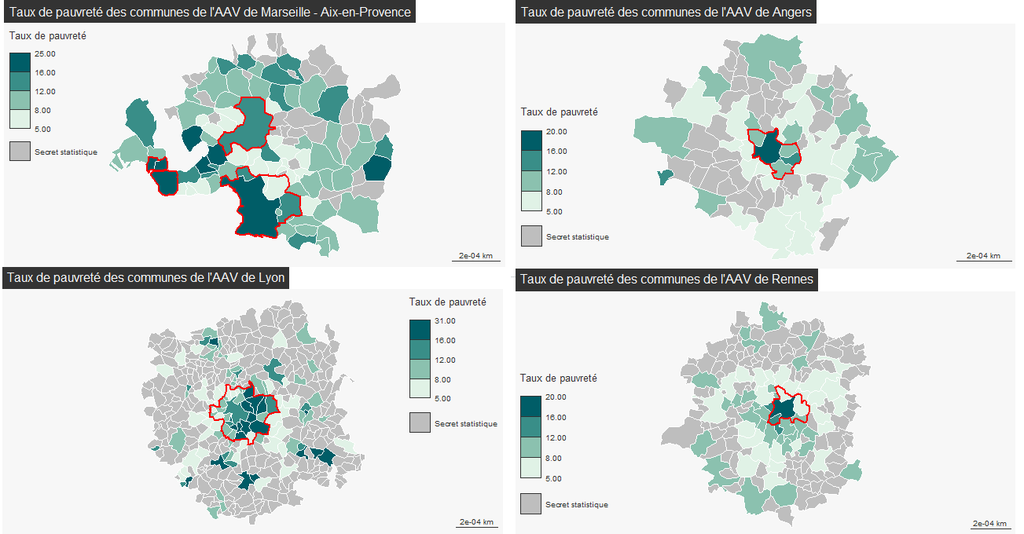

[output not shown]